# Excercise 5 - Dimensionality reduction techniques

## Introduction and data

We are using the `human` dataset, which originates from the United Nations Development Programme. This dataset has `8` variables and `155` observations, all of which are different countries. The variables and descriptions are shown below.

| Variable | Explanation |
| --- | --- |
| mat.mort | Maternal mortality |
| ado.BR | Adolescent birth rate |
| parl.rep | Female share of parliamentary seats |
| eduratio | Ratio of F to M with secondary education |
| laboratio | Ratio of F to M in labour force |
| life.exp | Life expectancy at birth |
| edu.exp | Excpected years of schooling |
| GNI.pc | Gross national income per capita |

```r
# ggpairs(human)
```

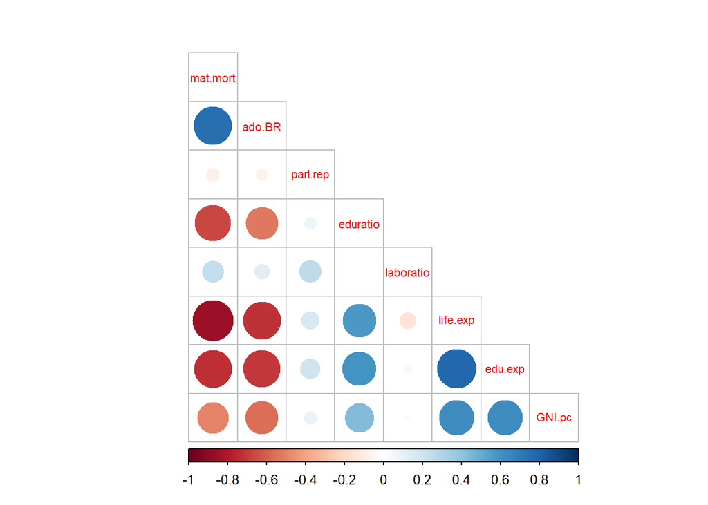

```r
corrplot(cor(human), method="circle", type="lower", cl.pos="b", tl.pos="d", tl.cex=0.7)
```

The correlations are better visualized here. For example: Strong correlation between *Maternal mortality* and *Adolescent birth rate.*

```r
humansummary <- summary(human)
kable(humansummary)
```

|  | mat.mort | ado.BR | parl.rep | eduratio | laboratio | life.exp | edu.exp | GNI.pc |
| --- | --- | --- | --- | --- | --- | --- | --- | --- |
|  | Min. : 1.0 | Min. : 0.60 | Min. : 0.00 | Min. :0.1717 | Min. :0.1857 | Min. :49.00 | Min. : 5.40 | Min. : 581 |
|  | 1st Qu.: 11.5 | 1st Qu.: 12.65 | 1st Qu.:12.40 | 1st Qu.:0.7264 | 1st Qu.:0.5984 | 1st Qu.:66.30 | 1st Qu.:11.25 | 1st Qu.: 4198 |
|  | Median : 49.0 | Median : 33.60 | Median :19.30 | Median :0.9375 | Median :0.7535 | Median :74.20 | Median :13.50 | Median : 12040 |
|  | Mean : 149.1 | Mean : 47.16 | Mean :20.91 | Mean :0.8529 | Mean :0.7074 | Mean :71.65 | Mean :13.18 | Mean : 17628 |
|  | 3rd Qu.: 190.0 | 3rd Qu.: 71.95 | 3rd Qu.:27.95 | 3rd Qu.:0.9968 | 3rd Qu.:0.8535 | 3rd Qu.:77.25 | 3rd Qu.:15.20 | 3rd Qu.: 24512 |
|  | Max. :1100.0 | Max. :204.80 | Max. :57.50 | Max. :1.4967 | Max. :1.0380 | Max. :83.50 | Max. :20.20 | Max. :123124 |

Above are summaries of variables. Maternal mortality is n/100000 births, and Adolescent birth rate is births / 1000 females aged 15-19.

## Principal component analysis

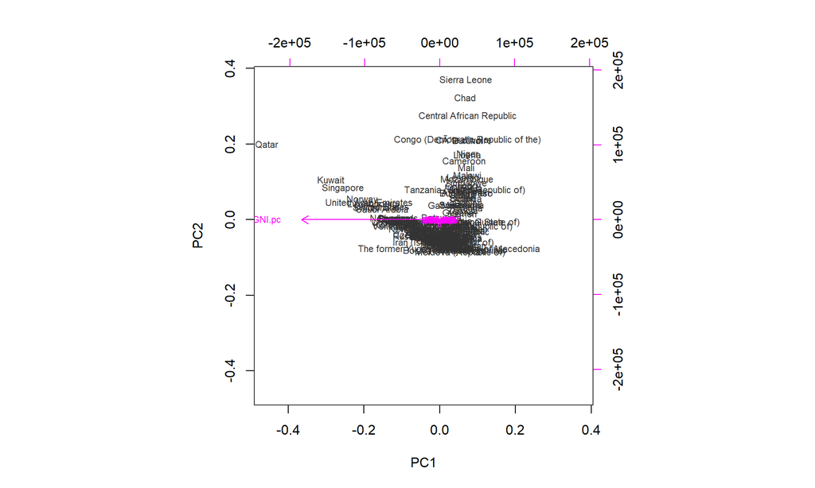

```r
#perform PCA on unscaled human data
pca_human1 <- prcomp(human)

# draw a biplot of the principal component representation and the original variables
biplot(pca_human1, choices = 1:2, cex = c(0.7, 0.7), col = c("grey20", "magenta"))
```

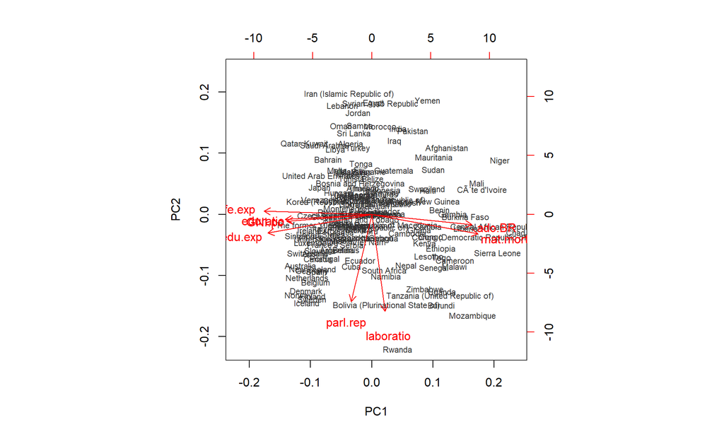

```r
#scale with default options (center to 0 and divide by SD)
human2 <- scale(human)
#perform PCA on scaled human data
pca_human2 <- prcomp(human2)

# draw a biplot of the principal component representation and the original variables
biplot(pca_human2, choices = 1:2, cex = c(0.7, 1.0), col = c("grey20", "red"))
```

This looks better. Principal component 1 is affected by 6 out of 8 variables in the data to a similar degree. Adolescent birth rate and maternal mortality are positively correlated, but negatively correlated with the following group of phenomenons, (which again are positively correlated): life expectancy, education expectancy, ratio of females to males receiving secondary education, and GNI per capita. Uncorrelated with the previous, but correlated with eachother are percentage of females in parliament, and ratio of females to males in the labour force. These two affect the secondary principal component.

So i conclude that GNI, and availability of education - for both genders are positively correlated with life expectancy, and adolescent births and maternal mortality are inversely correlated with these. Percentage of females in the work force and as representatives in parliament are not correlated with the phenomenons above.

## Tea Time

We have a look at questionnaire data regarding consumption of tea. The data is included in the `FactomineR` package. I choose a few variables wich would be interesting for me as a tearoom owner. Structure of the chosen data and a summary are seen below.

```r
library(FactoMineR)
library(tidyr)
data(tea)

keeptea=c("Tea","sugar","tea.time","tearoom","SPC","sex","resto","pub","How","how","friends")

# select the 'keeptea' to create a new dataset
tea_kept <- select(tea, one_of(keeptea))

# look at the summaries and structure of the data

summary(tea_kept)
```

```
##         Tea           sugar             tea.time          tearoom
##  black    : 74   No.sugar:155   Not.tea time:131   Not.tearoom:242
##  Earl Grey:193   sugar   :145   tea time    :169   tearoom    : 58
##  green    : 33
##
##
##
##
##            SPC     sex           resto          pub         How
##  employee    :59   F:178   Not.resto:221   Not.pub:237   alone:195
##  middle      :40   M:122   resto    : 79   pub    : 63   lemon: 33
##  non-worker  :64                                         milk : 63
##  other worker:20                                         other:  9
##  senior      :35
##  student     :70
##  workman     :12
##                  how             friends
##  tea bag           :170   friends    :196
##  tea bag+unpackaged: 94   Not.friends:104
##  unpackaged        : 36
##
##
##
##
```

```r
str(tea_kept)
```

```
## 'data.frame':    300 obs. of  11 variables:
##  $ Tea     : Factor w/ 3 levels "black","Earl Grey",..: 1 1 2 2 2 2 2 1 2 1 ...
##  $ sugar   : Factor w/ 2 levels "No.sugar","sugar": 2 1 1 2 1 1 1 1 1 1 ...
##  $ tea.time: Factor w/ 2 levels "Not.tea time",..: 1 1 2 1 1 1 2 2 2 1 ...
##  $ tearoom : Factor w/ 2 levels "Not.tearoom",..: 1 1 1 1 1 1 1 1 1 2 ...
##  $ SPC     : Factor w/ 7 levels "employee","middle",..: 2 2 4 6 1 6 5 2 5 5 ...
##  $ sex     : Factor w/ 2 levels "F","M": 2 1 1 2 2 2 2 1 2 2 ...
##  $ resto   : Factor w/ 2 levels "Not.resto","resto": 1 1 2 1 1 1 1 1 1 1 ...
##  $ pub     : Factor w/ 2 levels "Not.pub","pub": 1 1 1 1 1 1 1 1 1 1 ...
##  $ How     : Factor w/ 4 levels "alone","lemon",..: 1 3 1 1 1 1 1 3 3 1 ...
##  $ how     : Factor w/ 3 levels "tea bag","tea bag+unpackaged",..: 1 1 1 1 1 1 1 1 2 2 ...
##  $ friends : Factor w/ 2 levels "friends","Not.friends": 2 2 1 2 2 2 1 2 2 2 ...
```

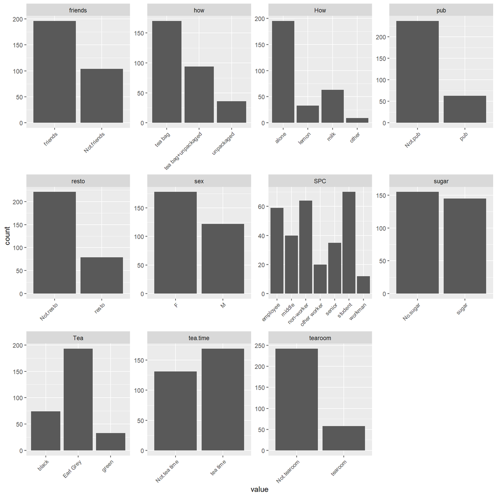

```r
# visualize the dataset
gather(tea_kept) %>% ggplot(aes(value)) +geom_bar() + facet_wrap("key", scales = "free") + theme(axis.text.x = element_text(angle = 45, hjust = 1, size = 8))
```